# CASE STUDY 2025/26: MODELOWANIE SPRZEDAŻY GIER KOMPUTEROWYCH

Victoria Bełz

## BUSINESS UNDERSTANDING (zrozumienie uwarunkowań biznesowych)

Celem projektu jest zbudowanie modelu regresyjnego, który będzie przewidywał **globalną sprzedaż gry komputerowej** na podstawie jej kluczowych cech. Analizowany zbiór danych “Video Games - Sales.csv” zawiera informacje o grach wydanych w latach **1980-2010**, obejmując m.in. platformę, gatunek, wydawcę, rok premiery oraz regionalne dane sprzedażowe.

W ramach zadania wylosowanym modelem podstawowym jest **MLP (Multi-Layer Perceptron),** natomiast drugim, samodzielnie wybranym modelem regresyjnym jest **Random Forest**, który ze względu na strukturę danych (duża ilość obserwacji, zmienne kategoryczne oraz potencjalna nieliniowość zależności) stanowi uzasadniony wybór.

Modelowanie opiera się na zestawie dostępnych i pochodnych cech opisujących **każdą grę**:

- platforma
- gatunek
- wydawca
- rok wydania
- wiek gry (cecha pochodna wyznaczona na podstawie roku wydania, opisująca kontekst czasowy premiery)
- dekada premiery (pochodna zmienna kategoryczna)
- seria gry (cecha pochodna wyodrębniona z nazwy)

Głównym celem projektu jest ocena, w jakim stopniu powyższe cechy pozwalają **przewidzieć wielkość globalnej sprzedaży gier komputerowych** a także porównanie predykcji modeli **MLP i Random Forest** na zbiorze testowym (4 obserwacje) oraz walidacyjnym (15% obserwacji).

Ze względu na bardzo niewielką liczność zbioru testowego uzyskane metryki mają charakter poglądowy i służą **głównie do porównania modeli**, a nie do pełnej oceny ich jakości predykcyjnej.

## DATA UNDERSTANDING (zrozumienie danych)

W tym kroku analizowany jest wylosowany zbiór danych “Video Games - Sales.csv”. Dane zawierają informacje identyfikujące gry (nazwa, platforma, gatunek, wydawca), rok wydania (`Release.Year`) oraz sprzedaż na czterech głównych rynkach: Ameryka Północna (`NA_Sales`), Europa (`EU_Sales`), Japonia (`JP_Sales`) i pozostałe regiony (`Other_Sales`) wraz z łączną globalną sprzedażą (`Global_Sales`). Zmienne sprzedażowe są wyrażone w milionach egzemplarzy (mln).

```r
#BIBLIOTEKI:
library(tidyverse)
library(caret)
library(nnet)
library(randomForest)
library(ranger)
```

```r
library(stringr)
library(corrplot)
set.seed(127)
```

```r
#WCZYTANIE DANYCH + SZYBKA EKSPLORACJA
vg <- read.csv("Video Games - Sales.csv", sep = ",", header = TRUE)

head(vg)
```

```
##                       Name Platform Release.Year        Genre Publisher
## 1               Wii Sports      Wii         2006       Sports  Nintendo
## 2        Super Mario Bros.      NES         1985     Platform  Nintendo
## 3           Mario Kart Wii      Wii         2008       Racing  Nintendo
## 4        Wii Sports Resort      Wii         2009       Sports  Nintendo
## 5 Pokemon Red/Pokemon Blue       GB         1996 Role-Playing  Nintendo
## 6                   Tetris       GB         1989       Puzzle  Nintendo
##   NA_Sales EU_Sales JP_Sales Other_Sales Global_Sales
## 1    41.49    29.02     3.77        8.46        82.74
## 2    29.08     3.58     6.81        0.77        40.24
## 3    15.85    12.88     3.79        3.31        35.83
## 4    15.75    11.01     3.28        2.96        33.00
## 5    11.27     8.89    10.22        1.00        31.38
## 6    23.20     2.26     4.22        0.58        30.26
```

```r
str(vg)
```

```
## 'data.frame':    12441 obs. of  10 variables:
##  $ Name        : chr  "Wii Sports" "Super Mario Bros." "Mario Kart Wii" "Wii Sports Resort" ...
##  $ Platform    : chr  "Wii" "NES" "Wii" "Wii" ...
##  $ Release.Year: int  2006 1985 2008 2009 1996 1989 2006 2006 2009 1984 ...
##  $ Genre       : chr  "Sports" "Platform" "Racing" "Sports" ...
##  $ Publisher   : chr  "Nintendo" "Nintendo" "Nintendo" "Nintendo" ...
##  $ NA_Sales    : num  41.5 29.1 15.8 15.8 11.3 ...
##  $ EU_Sales    : num  29.02 3.58 12.88 11.01 8.89 ...
##  $ JP_Sales    : num  3.77 6.81 3.79 3.28 10.22 ...
##  $ Other_Sales : num  8.46 0.77 3.31 2.96 1 0.58 2.9 2.85 2.26 0.47 ...
##  $ Global_Sales: num  82.7 40.2 35.8 33 31.4 ...
```

```r
summary(vg)
```

```
##      Name             Platform          Release.Year     Genre
##  Length:12441       Length:12441       Min.   :1980   Length:12441
##  Class :character   Class :character   1st Qu.:2002   Class :character
##  Mode  :character   Mode  :character   Median :2006   Mode  :character
##                                        Mean   :2004
##                                        3rd Qu.:2008
##                                        Max.   :2010
##   Publisher            NA_Sales          EU_Sales          JP_Sales
##  Length:12441       Min.   : 0.0000   Min.   : 0.0000   Min.   : 0.000
##  Class :character   1st Qu.: 0.0100   1st Qu.: 0.0000   1st Qu.: 0.000
##  Mode  :character   Median : 0.0900   Median : 0.0200   Median : 0.000
##                     Mean   : 0.2833   Mean   : 0.1404   Mean   : 0.084
##                     3rd Qu.: 0.2600   3rd Qu.: 0.1000   3rd Qu.: 0.030
##                     Max.   :41.4900   Max.   :29.0200   Max.   :10.220
##   Other_Sales        Global_Sales
##  Min.   : 0.00000   Min.   : 0.0000
##  1st Qu.: 0.00000   1st Qu.: 0.0700
##  Median : 0.01000   Median : 0.1800
##  Mean   : 0.04655   Mean   : 0.5543
##  3rd Qu.: 0.03000   3rd Qu.: 0.4900
##  Max.   :10.57000   Max.   :82.7400
```

```r
sum(is.na(vg)) #brak NA
```

```
## [1] 0
```

```r
sum(duplicated(vg)) #brak duplikatów
```

```
## [1] 0
```

```r
#zamiana sprzedaży na numeric
vg[, 6:10] <- lapply(vg[, 6:10], as.numeric)
sum(is.na(vg[, 6:10]))
```

```
## [1] 0
```

```r
#zamiana chr na factor
vg <- vg %>%
  mutate(
    Platform  = as.factor(Platform),
    Genre     = as.factor(Genre),
    Publisher = as.factor(Publisher)
  )

#sprawdzenie czy suma sprzedązy regionalnej = Global_Sales
vg$SumSales <- vg$NA_Sales + vg$EU_Sales + vg$JP_Sales + vg$Other_Sales
all(abs(vg$SumSales - vg$Global_Sales) < 0.01) #TRUE => zgodna dla każdej z gier
```

```
## [1] TRUE
```

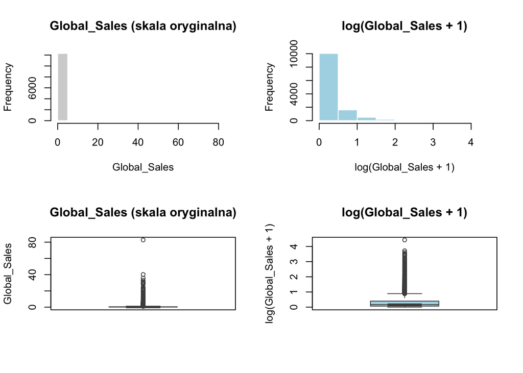

```r
vg <- vg %>% select(-SumSales)

#wykresy:
par(mfrow = c(2, 2))
hist(
  vg$Global_Sales,
  main   = "Global_Sales (skala oryginalna)",
  xlab  = "Global_Sales",
  col   = "lightgray",
  border = "white"
)

hist(
  log1p(vg$Global_Sales),
  main   = "log(Global_Sales + 1)",
  xlab  = "log(Global_Sales + 1)",
  col   = "lightblue",
  border = "white"
)

boxplot(
  vg$Global_Sales,
  main      = "Global_Sales (skala oryginalna)",
  ylab      = "Global_Sales",
  col       = "lightgray",
  border    = "gray30",
  outline   = TRUE,
  notch     = TRUE
)

boxplot(
  log1p(vg$Global_Sales),
  main      = "log(Global_Sales + 1)",
  ylab      = "log(Global_Sales + 1)",
  col       = "lightblue",
  border    = "gray30",
  outline   = TRUE,
  notch     = TRUE
)
```

```r
par(mfrow = c(1, 1))

#kwartyle + iqr + 3sigma
q <- quantile(vg$Global_Sales, probs = c(0.25, 0.5, 0.75), na.rm = TRUE)
iqr_val <- IQR(vg$Global_Sales, na.rm = TRUE)

q1 <- q[1]; med <- q[2]; q3 <- q[3]
cat("Kwartyle Global_Sales:\n")
```

```
## Kwartyle Global_Sales:
```

```r
cat("Q1 =", q1, "\n")
```

```
## Q1 = 0.07
```

```r
cat("Mediana =", med, "\n")
```

```
## Mediana = 0.18
```

```r
cat("Q3 =", q3, "\n")
```

```
## Q3 = 0.49
```

```r
cat("IQR =", iqr_val, "\n\n")
```

```
## IQR = 0.42
```

```r
low_iqr_out  <- q1 - 1.5 * iqr_val
high_iqr_out <- q3 + 1.5 * iqr_val
low_iqr_ext  <- q1 - 3.0 * iqr_val
high_iqr_ext <- q3 + 3.0 * iqr_val

is_outlier_iqr <- (vg$Global_Sales < low_iqr_out) | (vg$Global_Sales > high_iqr_out)
is_extreme_iqr <- (vg$Global_Sales < low_iqr_ext) | (vg$Global_Sales > high_iqr_ext)

cat("IQR 1.5*IQR: [", low_iqr_out, ",", high_iqr_out, "]\n")
```

```
## IQR 1.5*IQR: [ -0.56 , 1.12 ]
```

```r
cat("Liczba outlierów:", sum(is_outlier_iqr, na.rm = TRUE), "\n")
```

```
## Liczba outlierów: 1401
```

```r
cat("IQR 3*IQR: [", low_iqr_ext, ",", high_iqr_ext, "]\n")
```

```
## IQR 3*IQR: [ -1.19 , 1.75 ]
```

```r
cat("Liczba ekstremalnych:", sum(is_extreme_iqr, na.rm = TRUE), "\n\n")
```

```
## Liczba ekstremalnych: 765
```

```r
mu <- mean(vg$Global_Sales, na.rm = TRUE)
s  <- sd(vg$Global_Sales, na.rm = TRUE)
low_3s  <- mu - 3*s
high_3s <- mu + 3*s
is_outlier_3s <- (vg$Global_Sales < low_3s) | (vg$Global_Sales > high_3s)

cat("3σ: [", low_3s, ",", high_3s, "]\n")
```

```
## 3σ: [ -4.419639 , 5.528244 ]
```

```r
cat("Liczba outlierów:", sum(is_outlier_3s, na.rm = TRUE), "\n\n")
```

```
## Liczba outlierów: 118
```

```r
#Top10
top10_sales <- vg %>%
  arrange(desc(Global_Sales)) %>%
  select(Name, Platform, Genre, Publisher, Release.Year, Global_Sales) %>%
  head(10)
top10_sales
```

```
##                         Name Platform        Genre Publisher Release.Year
## 1                 Wii Sports      Wii       Sports  Nintendo         2006
## 2          Super Mario Bros.      NES     Platform  Nintendo         1985
## 3             Mario Kart Wii      Wii       Racing  Nintendo         2008
## 4          Wii Sports Resort      Wii       Sports  Nintendo         2009
## 5   Pokemon Red/Pokemon Blue       GB Role-Playing  Nintendo         1996
## 6                     Tetris       GB       Puzzle  Nintendo         1989
## 7      New Super Mario Bros.       DS     Platform  Nintendo         2006
## 8                   Wii Play      Wii         Misc  Nintendo         2006
## 9  New Super Mario Bros. Wii      Wii     Platform  Nintendo         2009
## 10                 Duck Hunt      NES      Shooter  Nintendo         1984
##    Global_Sales
## 1         82.74
## 2         40.24
## 3         35.83
## 4         33.00
## 5         31.38
## 6         30.26
## 7         30.01
## 8         29.01
## 9         28.61
## 10        28.31
```

Z eksploracji wynika, że:

- zbiór zawiera **ponad 12 tysięcy gier** oraz 10 zmiennych
- zakres lat wydań to 1980-2010 (min = 1980, max = 2010)
- brak jest wartości brakujących oraz duplikatów
- zmienne `Platform`, `Genre`, `Publisher`, które oryginalnie występują jako dane tekstowe, zostały zamienione na typ kategoryczny (factor)
- zmienne sprzedażowe zostały przekonwertowane na typ numeryczny
- suma sprzedaży regionalnej jest zgodna z `Global_Sales`(spójność danych) - test zgodności zwraca TRUE

Dodatkowo, analiza rozkładu `Global_Sales` wskazuje na **silnie prawostronną asymetrię**:

- histogram charakteryzuje się bardzo wysoką częstością obserwacji o niskiej sprzedaży (bliskiej zeru). Po zastosowaniu transformacji logarytmicznej rozkład nadal pozostaje prawoskośny, jednak staje się bardziej czytelny, a struktura danych w zakresie wyższych wartości sprzedaży jest lepiej widoczna
- statystyki opisowe: Global_Sales  
  ## Min. : 0.0000  
  ## 1st Qu.: 0.0700  
  ## Median : 0.1800  
  ## Mean : 0.5543  
  ## 3rd Qu.: 0.4900  
  ## Max. :82.7400
- duża różnica pomiędzy medianą a średnią potwierdza wpływ obserwacji o bardzo wysokiej sprzedaży na wartość średnią
- liczba wartości odstających wg metody IQR:
  - próg 1.5*IQR -> 1401 outlierów
  - próg 3*IQR -> 765 wartości ekstremalnych
- wg reguły 3*sigma wykryto 118 outlierów
- najwyższe wartości sprzedaży dotyczą pojedynczych hitów (np. “Wii Sports” ma 82.74), co dodatkowo potwierdza obecność silnych obserwacji ekstremalnych i długiego prawego ogona rozkładu

Nie oznacza to jednak konieczności ich usunięcia. Wartości te reprezentują rzeczywiste rynkowe hity, a nie błędy pomiarowe. Dlatego zamiast eliminacji obserwacji odstających, zdecydowano się na zastosowanie **transformacji logarytmicznej** (`log1p(Global_Sales)`). Zabieg ten pozwala ograniczyć wpływ wartości skrajnych i ustabilizować wariancję (zredukować skośność), zachowując jednocześnie kluczowe informacje o bestsellerach w modelu.

Na tym etapie nie obliczono współczynników korelacji ze względu na dominujący udział zmiennych o **charakterze kategorycznym**. Dopiero po zastosowaniu **target encodingu** przeprowadzono analizę korelacji pomiędzy zmiennymi oraz utworzono macierz współćzynników korelacji obliczonych metodami **Pearsona** oraz **Spearmana**.

## DATA PREPARATION (przygotowanie danych)

Etap przygotowania danych obejmuje oczyszczanie, transformację oraz tworzenie cech pochodnych, tak aby dane było odpowiednie dla modeli **MLP** oraz **Random Forest**. Pipeline został zaprojektowany tak, aby ograniczyć **wyciek informacji (data leakage)** poprzez wykonanie części transformacji **wyłącznie na zbiorze treningowym** i przenoszenie ich na walidację/test.

Wykonane kroki obejmują:

- **Feature Engineering - ekstrakcji serii gier (Franchise):** przed usunięciem identyfikatora tekstowego `Name`, wyodrębniono z niego pierwsze słowo, tworząc nową zmienną `Franchise`. Następnie poddano ją **standaryzacji tekstu:** usunięto końcówki (np. zamiana “Disney’s” na “Disney”) oraz znaki interpunkcyjne. Pozwoliło to na poprawne zgrupowanie gier w popularne serie. Dla 50 najpopularniejszych marek zachowano ich nazwy, a pozostałe (rzadkie) oznaczono jako “Other”. Po tej operacji usunięto kolumnę `Name` oraz gry ze sprzedażą równą 0.
- podział czasowy danych (sortowanie po `Release.Year`“) na:
  - **zbiór treningowy**,
  - **zbiór walidaycjny (15%)**
  - **zbiór testowy (ostatnie 4 obserwacje)**
- utworzenie cech pochodnych:
  - `Game_Age` – wiek gry liczony względem roku referencyjnego (`max_year`) wyznaczonego z TRAIN (brak wycieku)
  - `Decade` – dekada premiery (cecha kategoryczna)
- **Obsługa rzadkich kategorii (Frequent Level Filtering):** dla zmiennych `Platform`, `Genre`, `Publisher` oraz `Franchise` zdefiniowano listę kategorii częstych na podstawie zbioru TRAIN. Wszelkie wartości spoza tej listy (zarówno rzadkie, jak i nowe pojawiające się w teście) zamieniono na etykietę zbiorczą `Other`
  - progi rzadkości są liczone na TRAIN (0.05%)
  - a następnie stosowane na VALID/TEST
- **Target Encoding ze smoothingiem (`alpha = 50`)** dla `Platform`, `Genre`, `Publisher`, `Franchise`:
  - kodowanie oparte na średniej wartości zmiennej celu (LogSales), dopasowane wyłącznie na TRAIN.
  - dla kategorii niewystępujących w TRAIN przypisywana jest średnia globalna z TRAIN, co zapobiega **wyciekowi informacji (data leakage)**. (Początkowo występujący wyciek danych w starszych wersjach modelu powodował błędną estymację wyników).
- transformacja logarytmicznej zmiennej docelowej: modele uczą się na `LogSales = log1p(Global_Sales)` w celu zredukowania skośności; predykcje są odwracane do skali oryginalnej `Global_Sales` poprzez `expm1()`
- standaryzacja cech numerycznych **tylko na TRAIN** (wymóg MLP), a następnie zastosowanie tych samych parametrów skalowania na VALID/TEST

Nie uwzględniono zmiennych sprzedaży regionalnej (`NA_Sales`,`EU_Sales`, `JP_Sales`, `Other_Sales`), ponieważ stanowią one bezpośrednie składowe zmiennej docelowej `Global_Sales`. Ich pozostawienie wśród zmiennych niezależnych (cech wejściowych) prowadziłoby do wycieku informacji i sztucznie zawyżonej jakości modelu. Wykryte obserwacje odstające w `Global_Sales` traktowane są jako naturalne zjawisko rynkowe (bestsellery), a nie błędy danych. Dlatego zamiast usuwać takie obserwacje, **zastosowano transformację logarytmiczną** `log(1 + Global_Sales)`, która ogranicza wpływ wartości skrajnych i stabilizuje wariancję, zachowując jednocześnie informację o hitach sprzedażowych.

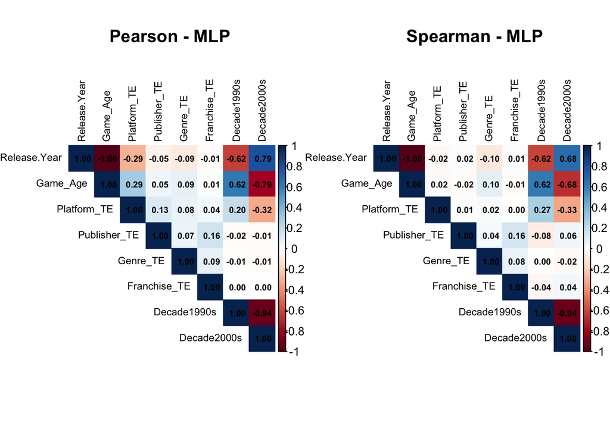

```r
#=============================================================================
#PARAMETRY:
VAL_FRAC  <- 0.15
N_TEST    <- 4
RARE_FRAC <- 0.05/100
TE_ALPHA  <- 50

#=============================================================================
#DATA PREPARATION (PRZYGOTOWANIE DANYCH)

#WSTEPNE CECHY Z NAZWY (Franchise) + CZYSZCZENIE
vg$Franchise <- word(vg$Name, 1)
vg$Franchise <- str_remove(vg$Franchise, "'s$")
vg$Franchise <- str_remove_all(vg$Franchise, "[:punct:]")
vg <- vg %>% filter(Global_Sales > 0) %>% select(-Name)

#PODZIAŁ CZASOWY (TRAIN, VALID, TEST)
vg_sorted <- vg[order(vg$Release.Year), ]
n <- nrow(vg_sorted)

n_val <- floor(VAL_FRAC * n)

idx_test <- n - N_TEST + 1
idx_val  <- idx_test - n_val

test  <- vg_sorted[idx_test:n, , drop = FALSE]
valid <- vg_sorted[idx_val:(idx_test - 1), , drop = FALSE]
train <- vg_sorted[1:(idx_val - 1), , drop = FALSE]

real_valid <- valid$Global_Sales
real_test  <- test$Global_Sales

#TOP50 FRANCHISE
top_franchises <- names(sort(table(train$Franchise), decreasing = TRUE))[1:50]

map_franchise_top50 <- function(x, top_levels){
  x_char <- as.character(x)
  x_char[!(x_char %in% top_levels)] <- "Other"
  factor(x_char, levels = unique(c(top_levels, "Other")))
}

train$Franchise <- map_franchise_top50(train$Franchise, top_franchises)
valid$Franchise <- map_franchise_top50(valid$Franchise, top_franchises)
test$Franchise  <- map_franchise_top50(test$Franchise,  top_franchises)

#CECHY POCHODNE (LOG, WIEK, DEKADA)
max_year <- max(train$Release.Year, na.rm = TRUE) + 1

add_features <- function(df, max_year){
  df %>%
    mutate(
      LogSales = log1p(Global_Sales),
      Game_Age = max_year - Release.Year,
      Decade   = factor(paste0(floor(Release.Year / 10) * 10, "s"))
    )
}

train <- add_features(train, max_year)
valid <- add_features(valid, max_year)
test  <- add_features(test,  max_year)

#RARE CATEGORY ENCODING
min_n <- max(1, round(RARE_FRAC * nrow(train)))

fit_frequent_levels <- function(x_train, min_n){
  tab <- table(as.character(x_train))
  names(tab[tab >= min_n])
}

apply_frequent_mask <- function(x, frequent_levels){
  x_char <- as.character(x)
  x_char[!(x_char %in% frequent_levels)] <- "Other"
  factor(x_char, levels = unique(c(frequent_levels, "Other")))
}

categorical_cols <- c("Platform", "Publisher", "Genre", "Franchise")

for (col in categorical_cols) {
  freq_levels <- fit_frequent_levels(train[[col]], min_n)

  train[[col]] <- apply_frequent_mask(train[[col]], freq_levels)
  valid[[col]] <- apply_frequent_mask(valid[[col]], freq_levels)
  test[[col]]  <- apply_frequent_mask(test[[col]],  freq_levels)
}

#POZIOMY DLA DEKAD
dec_levels <- unique(as.character(train$Decade))
dec_levels <- c(dec_levels, "Other")

map_decade <- function(x, levels_train){
  x_char <- as.character(x)
  x_char[!(x_char %in% levels_train)] <- "Other"
  factor(x_char, levels = levels_train)
}

train$Decade <- map_decade(train$Decade, dec_levels)
valid$Decade <- map_decade(valid$Decade, dec_levels)
test$Decade  <- map_decade(test$Decade,  dec_levels)

#TARGET ENCODING (ZE SMOOTHINGIEM)
encode_mean_multi_smooth <- function(train, valid, test, col, target, alpha = 50) {
  global_mean <- mean(train[[target]], na.rm = TRUE)

  stats <- train %>%
    group_by(across(all_of(col))) %>%
    summarise(
      n      = n(),
      mu_raw = mean(.data[[target]], na.rm = TRUE),
      .groups = "drop"
    ) %>%
    mutate(mu = (n * mu_raw + alpha * global_mean) / (n + alpha)) %>%
    select(all_of(col), mu)

  train2 <- left_join(train, stats, by = col)
  valid2 <- left_join(valid, stats, by = col)
  test2  <- left_join(test,  stats, by = col)

  train2$mu[is.na(train2$mu)] <- global_mean
  valid2$mu[is.na(valid2$mu)] <- global_mean
  test2$mu[is.na(test2$mu)]   <- global_mean

  new_name <- paste0(col, "_TE")
  names(train2)[ncol(train2)] <- new_name
  names(valid2)[ncol(valid2)] <- new_name
  names(test2)[ncol(test2)]   <- new_name

  list(train = train2, valid = valid2, test = test2)
}


for (col in categorical_cols) {
  out <- encode_mean_multi_smooth(train, valid, test, col, "LogSales", alpha = TE_ALPHA)
  train <- out$train
  valid <- out$valid
  test  <- out$test
}

#=============================================================================
# PRZYGOTOWANIE MACIERZY CECH (WERSJA DO KORELACJI)
decade_train <- model.matrix(~Decade, data=train)[, -1, drop=FALSE]
decade_valid <- model.matrix(~Decade, data=valid)[, -1, drop=FALSE]
decade_test  <- model.matrix(~Decade, data=test )[, -1, drop=FALSE]

x_train_mlp_corr <- data.frame(
  Release.Year = train$Release.Year,
  Game_Age     = train$Game_Age,
  Platform_TE  = train$Platform_TE,
  Publisher_TE = train$Publisher_TE,
  Genre_TE     = train$Genre_TE,
  Franchise_TE = train$Franchise_TE
) %>% cbind(decade_train)

train_rf_corr <- data.frame(
  Release.Year = train$Release.Year,
  Game_Age     = train$Game_Age,
  Platform_TE  = train$Platform_TE,
  Genre_TE     = train$Genre_TE,
  Publisher_TE = train$Publisher_TE,
  Franchise_TE = train$Franchise_TE,
  Decade       = train$Decade,
  LogSales     = train$LogSales
)

#usunięcie zmiennych o zerowej wariancji (DecadeOther)
nzv_corr <- nearZeroVar(x_train_mlp_corr)
x_train_mlp_corr <- x_train_mlp_corr[, -nzv_corr, drop = FALSE]



#=============================================================================
#KORELACJE PO ENCODINGU (TRAIN) – na wersji z Release.Year
par(mfrow = c(1, 2))

corr_mlp_pearson <- cor(x_train_mlp_corr,  method = "pearson")
corrplot(corr_mlp_pearson, method = "color", type = "upper",
         tl.cex = 0.7, tl.col = "black", addCoef.col = "black",
         number.cex = 0.6, number.digits = 2)
title("Pearson - MLP")

corr_mlp_spearman <- cor(x_train_mlp_corr, method = "spearman")
corrplot(corr_mlp_spearman, method = "color", type = "upper",
         tl.cex = 0.7, tl.col = "black", addCoef.col = "black",
         number.cex = 0.6, number.digits = 2)
title("Spearman - MLP")
```

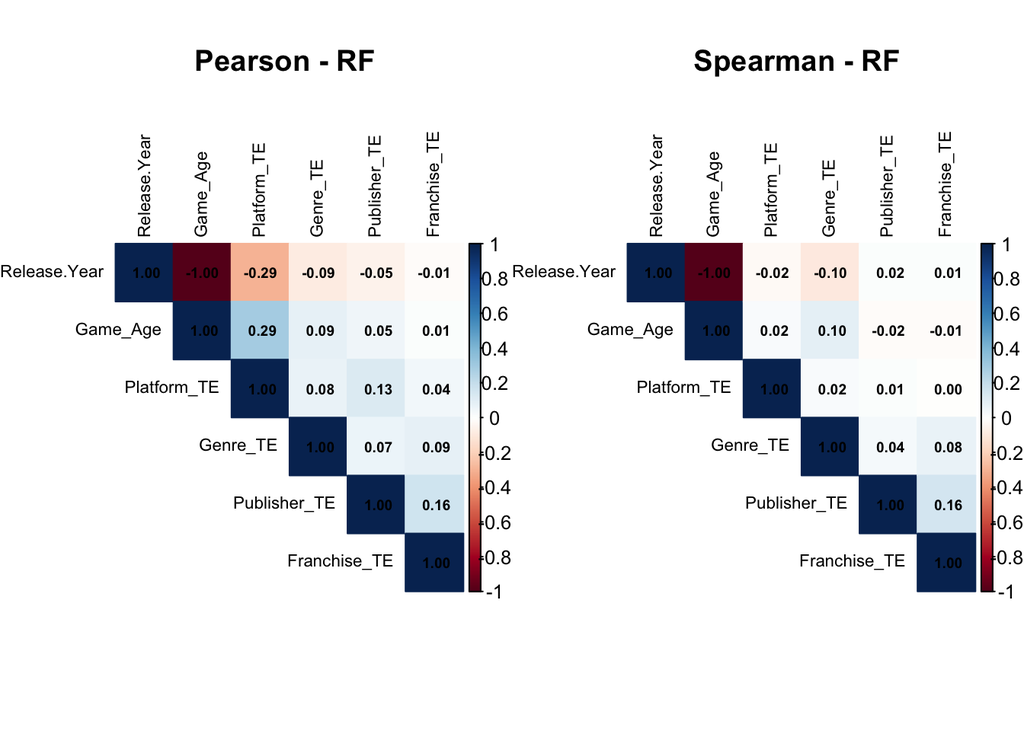

```r
rf_num <- train_rf_corr %>% select(where(is.numeric)) %>% select(-LogSales)
par(mfrow = c(1, 2))
corr_rf_pearson <- cor(rf_num, method = "pearson")
corrplot(corr_rf_pearson, method = "color", type = "upper",
         tl.cex = 0.7, tl.col = "black", addCoef.col = "black",
         number.cex = 0.6, number.digits = 2)
title("Pearson - RF")

corr_rf_spearman <- cor(rf_num, method = "spearman")
corrplot(corr_rf_spearman, method = "color", type = "upper",
         tl.cex = 0.7, tl.col = "black", addCoef.col = "black",
         number.cex = 0.6, number.digits = 2)
title("Spearman - RF")
```

```r
par(mfrow = c(1, 1))

#=============================================================================
#USUNIĘCIE Release.Year
train <- train %>% select(-Release.Year)
valid <- valid %>% select(-Release.Year)
test  <- test  %>% select(-Release.Year)

#=============================================================================
#PRZYGOTOWANIE MACIERZY CECH (WERSJA DO MODELI)

decade_train <- model.matrix(~Decade, data=train)[, -1, drop=FALSE]
decade_valid <- model.matrix(~Decade, data=valid)[, -1, drop=FALSE]
decade_test  <- model.matrix(~Decade, data=test )[, -1, drop=FALSE]

x_train_mlp <- data.frame(
  Game_Age     = train$Game_Age,
  Platform_TE  = train$Platform_TE,
  Publisher_TE = train$Publisher_TE,
  Genre_TE     = train$Genre_TE,
  Franchise_TE = train$Franchise_TE
) %>% cbind(decade_train)

x_valid_mlp <- data.frame(
  Game_Age     = valid$Game_Age,
  Platform_TE  = valid$Platform_TE,
  Publisher_TE = valid$Publisher_TE,
  Genre_TE     = valid$Genre_TE,
  Franchise_TE = valid$Franchise_TE
) %>% cbind(decade_valid)

x_test_mlp <- data.frame(
  Game_Age     = test$Game_Age,
  Platform_TE  = test$Platform_TE,
  Publisher_TE = test$Publisher_TE,
  Genre_TE     = test$Genre_TE,
  Franchise_TE = test$Franchise_TE
) %>% cbind(decade_test)

y_train_log <- train$LogSales
y_valid_log <- valid$LogSales
y_test_log  <- test$LogSales

#usuwanie zmiennych o zerowej wariancji
nzv <- nearZeroVar(x_train_mlp)
if (length(nzv) > 0) {
  x_train_mlp <- x_train_mlp[, -nzv, drop = FALSE]
  x_valid_mlp <- x_valid_mlp[, colnames(x_train_mlp), drop = FALSE]
  x_test_mlp  <- x_test_mlp[,  colnames(x_train_mlp), drop = FALSE]
}

#skalowanie (tylko na TRAIN) – MLP
preproc_mlp <- preProcess(x_train_mlp, method = c("center", "scale"))
x_train_mlp_scaled <- predict(preproc_mlp, x_train_mlp)
x_valid_mlp_scaled <- predict(preproc_mlp, x_valid_mlp)
x_test_mlp_scaled  <- predict(preproc_mlp, x_test_mlp)

train_mlp <- data.frame(x_train_mlp_scaled, LogSales = y_train_log)
valid_mlp <- data.frame(x_valid_mlp_scaled, LogSales = y_valid_log)
test_mlp  <- data.frame(x_test_mlp_scaled)

#RANDOM FOREST (bez Release.Year)
train_rf <- data.frame(
  Game_Age     = train$Game_Age,
  Platform_TE  = train$Platform_TE,
  Genre_TE     = train$Genre_TE,
  Publisher_TE = train$Publisher_TE,
  Franchise_TE = train$Franchise_TE,
  Decade       = train$Decade,
  LogSales     = y_train_log
)

valid_rf <- data.frame(
  Game_Age     = valid$Game_Age,
  Platform_TE  = valid$Platform_TE,
  Genre_TE     = valid$Genre_TE,
  Publisher_TE = valid$Publisher_TE,
  Franchise_TE = valid$Franchise_TE,
  Decade       = valid$Decade
)

test_rf <- data.frame(
  Game_Age     = test$Game_Age,
  Platform_TE  = test$Platform_TE,
  Genre_TE     = test$Genre_TE,
  Publisher_TE = test$Publisher_TE,
  Franchise_TE = test$Franchise_TE,
  Decade       = test$Decade
)
```

### Wspołczynniki korelacji Pearsona i Spearmana

Po zastosowaniu **target encodingu** zmiennych kategorycznych wszystkie cechy wejściowe przyjęły postać liczbową, co umożliwiło przeprowadzenie analizy zależności liniowych i monotonicznych pomiędzy zmiennymi niezależnymi

Obliczono **współczynniki korelacji Pearsona oraz Spearmana** wyłącznie na **zbiorze treningowym**, aby uniknąć wycieku informacji (data leakage).

Korelacje Pearsona pozwalają ocenić **siłę zależności liniowych**, istotnych szczególnie w kontekście modelu MLP. Korelacje rang Spearmana są bardziej odporne na obserwacje odstające i umożliwiają identyfikację **zależności monotonicznych** nawet w przypadku nieliniowości.

Analiza macierzy korelacji wskazuje, że:

- większość cech wykazuje **niskie lub umiarkowane wartości współczynników korelacji**, co ogranicza ryzyko silnej współliniowości
- cechy pochodne związane z czasem (np. `Release.Year`, `Game_Age`) są ze sobą **silnie skorelowane**, co jest naturalną konsekwencją ich definicji
- brak bardzo wysokich korelacji pomiędzy pozostałymi cechami sugeruje, że każda z nich wnosi częściowo odrębną informację predykcyjną do modelu.

Ze względu na bardzo silną korelację pomiędzy zmiennymi `Release.Year` oraz `Game_Age`, wynikającą z ich liniowego powiązania, zmienne te niosły w dużej mierze tę samą informację. W celu ograniczenia redundancji cech zdecydowano się usunąć zmienną `Release.Year`, pozostawiając Game_Age, która w bardziej bezpośredni sposób opisuje kontekst czasowy gry i jej „wiek rynkowy”.

## MODELING (modelowanie)

Na tym etapie zbudowano dwa modele regresyjne rozwiązujące ten sam problem, polegający na przewidywaniu **zlogarytmizowanej globalnej sprzedaży gier (`LogSales`)**:

**1. Model 1: MLP (Multi-Layer Perceptron)** - model wylosowany. **2. Model 2: Random Forest** - model samodzielnie wybrany (wersja regresyjna)

Oba modele trenowane są na tym samym zestawie cech wejściowych oraz na tej samej zmiennej zależnej, co umożliwia ich bezpośrednie porównanie pod względem jakości predykcji. Modele uczone są na zmiennej `LogSales`, jednak wszystkie metryki oraz końcowa interpretacja wyników odnoszą się do oryginalnej skali sprzedaży (`Global_Sales`, w mln egzemplarzy), po odwróceniu transformacji logarytmicznej.

**Model 1: MLP (Multi-Layer Perceptron)**

Do budowy MLP zastosowano klasyczną sieć neuronową (`nnet`) z **jedną warstwą ukrytą** . Ze względu na wrażliwość sieci neuronowych na skalę danych, wszystkie cechy numeryczne zostały wcześniej **zestandaryzowane** na podstawie zbioru treningowego.

Proces uczenia został podzielony na dwa etapy:

**1. Strojenie hiperparametrów (tuning):**

Najlepsza kombinacja została automatycznie wybrana na podstawie wyników funkcji `train()` z pakietu `caret`

**2. Uczenie modelu finalnego:**

- model MLP z wybranymi hiperparametrami został ponownie wytrenowany na **pełnym zbiorze treningowym**
- predykcje wyznaczono w skali logarytmicznej (`LogSales`), a następnie przekształcono do skali rzeczywistej sprzedaży (`Global_Sales`) przy użyciu funkcji odwrotnej do transformacji logarytmicznej (`expm1()`), z ograniczeniem do wartości nieujemnych

**Model 2: Random Forest**

Drugim rozważanym modelem jest **Random Forest w wersji regresyjnej**, będący zespołem wielu drzew decyzyjnych. Model ten dobrze radzi sobie z **nieliniowościami** oraz **interakcjami pomiędzy cechami** i nie wymaga standaryzacji danych wejściowych.

Podobnie jak w przypadku MLP, proces modelowania został podzielony na dwa etapy.

**1. Strojenie hiperparametrów:**

- strojenie wykonano na **podzbiorze końcówki zbioru treningowego** (maksymalnie 3500 obserwacji)
- zastosowano walidację czasową typu `timeslice` z krokiem `skip=5`
- przeszukano siatkę hiperparametrów:
  - `mtry` - liczba losowo wybieranych predyktorów przy każdym podziale drzewa; testowane wartości : {sqrt(p), p/3, p/2}
  - `min.node.size` - minimalna liczba obserwacji w liściu drzewa (testowane wartosci: `1`, `3`, `5`, `10`)
  - `splitrule` - reguła podziału węzła (“variance” oraz “extratrees”).
- liczba drzew w fazie strojenia została ustalona na **400**
- jako miarę ważności cech zastosowano **permutation importance**
- kryterium wyboru modelu była minimalizacja **RMSE**

**2. Uczenie modelu finalnego:**

- model RF z optymalnymi hiperparametrami został ponownie wytrenowany na **pełnym zbiorze treningowym**
- zwiększono liczbę drzew do **600**, w celu uzyskania stabilniejszych predykcji
- predykcje, analogicznie jak w modelu MLP, zostały przekształcone z log-skali do skali `Global_Sales`

```r
#=============================================================================
# POZBIÓR DO TUNINGU (Ostatnie 3500 gier z TRAIN)
train_sub_mlp <- tail(train_mlp, min(3500, nrow(train_mlp)))
train_sub_rf  <- tail(train_rf,  min(3500, nrow(train_rf)))

#=============================================================================
# MODEL 1: MLP
n_sub <- nrow(train_sub_mlp)
p <- ncol(train_sub_mlp) - 1  #minus LogSales!
h0 <- round((p + 1) / 2)

size_grid <- unique(pmax(2, c(h0 - 4, h0 - 2, h0, h0 + 2, h0 + 4)))
size_grid <- size_grid[size_grid <= 25]

initialWindow <- max(2000, floor(0.75 * n_sub))
horizon       <- max(400,  floor(0.15 * n_sub))
horizon       <- min(horizon, initialWindow - 1)

ctrl_mlp <- trainControl(
  method        = "timeslice",
  initialWindow = initialWindow,
  horizon       = horizon,
  fixedWindow   = TRUE,
  skip          = 5,
  verboseIter   = FALSE,
  allowParallel = TRUE
)

grid_mlp <- expand.grid(
  size  = size_grid,
  decay = c(0, 1e-5, 1e-4, 1e-3, 1e-2, 1e-1)
)

set.seed(127)
mlp_tuned <- train(
  LogSales ~ .,
  data      = train_sub_mlp,
  method    = "nnet",
  trControl = ctrl_mlp,
  tuneGrid  = grid_mlp,
  metric    = "RMSE",
  linout    = TRUE,
  trace     = FALSE,
  maxit     = 500,
  MaxNWts   = 20000
)

best_mlp <- mlp_tuned$bestTune

#=============================================================================
# MODEL FINALNY MLP
set.seed(127)
mlp_final <- train(
  LogSales ~ .,
  data      = train_mlp,
  method    = "nnet",
  trControl = trainControl(method = "none"),
  tuneGrid  = best_mlp,
  linout    = TRUE,
  trace     = FALSE,
  maxit     = 800,
  MaxNWts   = 20000
)

#=============================================================================
# MODEL 2: RANDOM FOREST - TUNING TIMESLICE PRZEZ RANGER
n_sub_rf <- nrow(train_sub_rf)

initialWindow_rf <- max(2000, floor(0.75 * n_sub_rf))
horizon_rf       <- max(400,  floor(0.15 * n_sub_rf))
horizon_rf       <- min(horizon_rf, initialWindow_rf - 1)

ctrl_rf <- trainControl(
  method        = "timeslice",
  initialWindow = initialWindow_rf,
  horizon       = horizon_rf,
  fixedWindow   = TRUE,
  skip          = 5,
  verboseIter   = FALSE,
  allowParallel = TRUE
)

p_rf <- ncol(train_sub_rf) - 1
mtry_vals <- unique(pmax(1, c(floor(sqrt(p_rf)), floor(p_rf/3), floor(p_rf/2))))
mtry_vals <- mtry_vals[mtry_vals <= p_rf]

grid_rf <- expand.grid(
  mtry          = mtry_vals,
  splitrule     = c("variance", "extratrees"),
  min.node.size = c(1, 3, 5, 10)
)

set.seed(127)
rf_tuned <- train(
  LogSales ~ .,
  data       = train_sub_rf,
  method     = "ranger",
  trControl  = ctrl_rf,
  tuneGrid   = grid_rf,
  metric     = "RMSE",
  num.trees  = 400,
  importance = "permutation"
)

best_rf <- rf_tuned$bestTune

#MODEL FINALNY RF
set.seed(127)
rf_final <- train(
  LogSales ~ .,
  data       = train_rf,
  method     = "ranger",
  trControl  = trainControl(method = "none"),
  tuneGrid   = best_rf,
  num.trees  = 600,
  importance = "permutation"
)

#=============================================================================
#PREDYKCJE + POWRÓT DO ORYGINALNEJ SKALI
pred_mlp_valid <- pmax(0, expm1(predict(mlp_final, newdata = valid_mlp)))
pred_mlp_test  <- pmax(0, expm1(predict(mlp_final, newdata = test_mlp)))

pred_rf_valid  <- pmax(0, expm1(predict(rf_final, newdata = valid_rf)))
pred_rf_test   <- pmax(0, expm1(predict(rf_final, newdata = test_rf)))
```

## EVALUATION (ewaluacja)

Celem etapu była ilościowa i jakościowa ocena jakości predykcji modeli **MLP** oraz **Random Forest**. Ocenę przeprowadzono osobno na zbiorze **walidacyjnym (VALID)** oraz **testowym (TEST, n = 4)**.

Modele trenowane były na zlogarytmizowanej zmiennej docelowej (`LogSales`), natomiast wszystkie metryki obliczono po **odwróceniu transformacji logarytmicznej** do skali rzeczywistej sprzedaży (`Global_Sales`), co umożliwia ich interpretację w jednostkach oryginalnych.

Ze względu na bardzo małą liczebność zbioru testowego, uzyskane wyniki na zbiorze TEST należy traktować **poglądowo**, a główny nacisk położono na porównanie modeli na zbiorze walidacyjnym.

Zastosowane metryki: - **RMSE (Root Mean Squared Error)** - pierwiastek z średniego błędu kwadratowego; silnie karze duże błędy, wrażliwy na obserwacje odstające - **MAE (Mean Absolute Error)** - średni błąd bezwzględny - **MedAE (Median Absolute Error)** - medianowy błąd bezwględny, bardziej odporny na outliery niz MAE - **sMAPE (Symmetric Mean Absolute Percentage Error)** - symetryczny błąd procentowy. Przy bardzo małych wartościach rzeczywistych (blisko 0) sMAPE potrafi gwałtownie rosnąć - **RMSLE (Root Mean Squared Log Error)** - RMSE liczone na skali logarytmicznej (log1p); ogranicza wpływ dużych wartości - **R^2 (Współczynnik determinacji)** – miara dopasowania modelu; określa, jaka część zmienności zmiennej zależnej jest wyjaśniana przez model. - **ME (Mean Error / bias )** - średni błąd (obciążenie); informuje, czy model systematycznie zawyża lub zaniża prognozy.

Zastosowane wykresy diagnostyczne:

- **QQ-plot reszt** - służy do oceny zgodności rozkładu reszt z rozkładem normalnym; silne odchylenia w prawym ogonie wskazują na obecność obserwacji odstających oraz trudności modeli w predykcji gier o bardzo wysokiej sprzedaży.
- **Reszty vs predykcje** - pozwala ocenić strukturę błędów oraz sprawdzić, czy ich wariancja zależy od poziomu predykcji; rosnący rozrzut reszt dla wyższych predykcji sugeruje heteroscedastyczność.
- **Rzeczywiste vs predykcje** - umożliwia bezpośrednią ocenę jakości dopasowania modelu; systematyczne odchylenia punktów od przekątnej wskazują na niedoszacowanie bardzo wysokich wartości sprzedaży przez oba modele.

```r
#=============================================================================
#METRYKI:

rmse  <- function(y, yhat) sqrt(mean((y - yhat)^2, na.rm = TRUE))
mae   <- function(y, yhat) mean(abs(y - yhat), na.rm = TRUE)
medae <- function(y, yhat) median(abs(y - yhat), na.rm = TRUE)
smape <- function(y, yhat) mean(abs(y - yhat) / ((abs(y) + abs(yhat))/2 + 1e-6), na.rm = TRUE) * 100
rmsle <- function(y, yhat) sqrt(mean((log1p(y) - log1p(yhat))^2, na.rm = TRUE))
r2 <- function(y, yhat){
  ss_res <- sum((y - yhat)^2, na.rm = TRUE)
  ss_tot <- sum((y - mean(y, na.rm = TRUE))^2, na.rm = TRUE)
  1 - ss_res/ss_tot
}
me <- function(y, yhat) mean(yhat - y, na.rm = TRUE)


results_valid <- data.frame(
  Split = "VALID",
  Model = c("MLP", "Random Forest"),
  RMSE  = c(rmse(real_valid, pred_mlp_valid), rmse(real_valid, pred_rf_valid)),
  MAE   = c(mae(real_valid,  pred_mlp_valid),  mae(real_valid, pred_rf_valid)),
  MedAE = c(medae(real_valid, pred_mlp_valid), medae(real_valid, pred_rf_valid)),
  sMAPE = c(smape(real_valid, pred_mlp_valid), smape(real_valid, pred_rf_valid)),
  RMSLE = c(rmsle(real_valid, pred_mlp_valid), rmsle(real_valid, pred_rf_valid)),
  R2    = c(r2(real_valid, pred_mlp_valid),    r2(real_valid, pred_rf_valid)),
  ME    = c(me(real_valid, pred_mlp_valid),    me(real_valid, pred_rf_valid))
)

results_test <- data.frame(
  Split = paste0("TEST (n=", N_TEST, ")"),
  Model = c("MLP", "Random Forest"),
  RMSE  = c(rmse(real_test, pred_mlp_test), rmse(real_test, pred_rf_test)),
  MAE   = c(mae(real_test, pred_mlp_test),  mae(real_test, pred_rf_test)),
  MedAE = c(medae(real_test, pred_mlp_test), medae(real_test, pred_rf_test)),
  sMAPE = c(smape(real_test, pred_mlp_test), smape(real_test, pred_rf_test)),
  RMSLE = c(rmsle(real_test, pred_mlp_test), rmsle(real_test, pred_rf_test)),
  R2    = c(r2(real_test, pred_mlp_test),    r2(real_test, pred_rf_test)),
  ME    = c(me(real_test, pred_mlp_test),    me(real_test, pred_rf_test))
)

results_all <- rbind(results_valid, results_test)

results_all_round <- results_all %>% mutate(across(where(is.numeric), ~round(.x, 4)))
results_all_round
```

```
##        Split         Model   RMSE    MAE  MedAE    sMAPE  RMSLE     R2      ME
## 1      VALID           MLP 1.0025 0.3400 0.1611 117.0006 0.2955 0.1416 -0.0114
## 2      VALID Random Forest 1.0108 0.3915 0.2553 115.3902 0.3080 0.1274  0.0739
## 3 TEST (n=4)           MLP 0.2640 0.1898 0.1500 171.4748 0.2205   -Inf  0.1848
## 4 TEST (n=4) Random Forest 0.3900 0.3866 0.3994 189.9924 0.3255   -Inf  0.3866
```

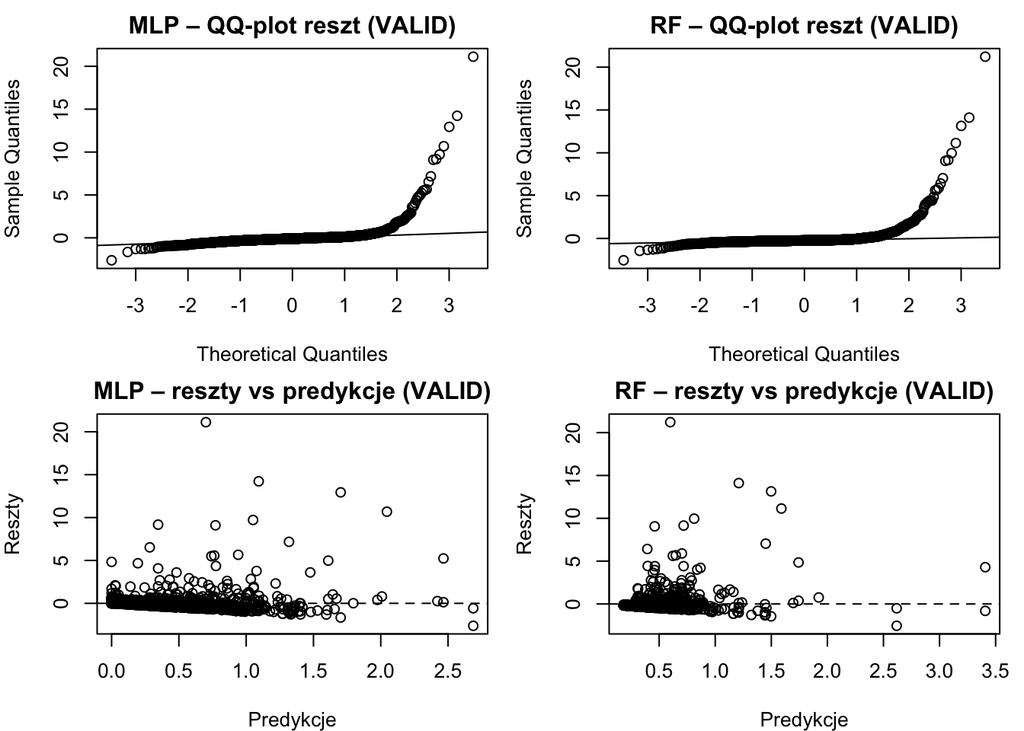

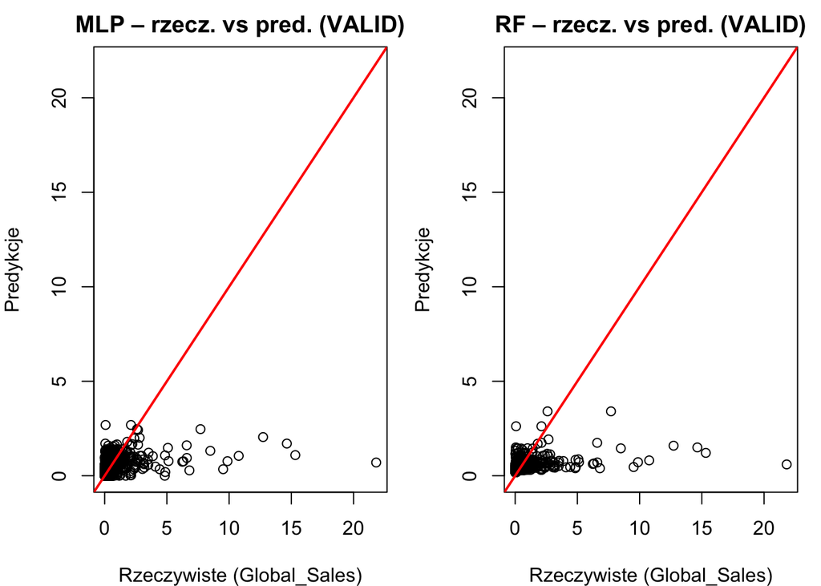

```r
#=============================================================================
#WYKRESY DIAGNOSTYCZNE:

plot_diagnostics <- function(real, pred_mlp, pred_rf, label = "VALID") {
  res_mlp <- real - pred_mlp
  res_rf  <- real - pred_rf

  op <- par(no.readonly = TRUE)
  on.exit(par(op))

  par(mfrow = c(2, 2), mar = c(4, 4, 2, 1))

  qqnorm(res_mlp, main = paste0("MLP – QQ-plot reszt (", label, ")"))
  qqline(res_mlp)

  qqnorm(res_rf, main = paste0("RF – QQ-plot reszt (", label, ")"))
  qqline(res_rf)

  plot(pred_mlp, res_mlp,
       main = paste0("MLP – reszty vs predykcje (", label, ")"),
       xlab = "Predykcje", ylab = "Reszty")
  abline(h = 0, lty = 2)

  plot(pred_rf, res_rf,
       main = paste0("RF – reszty vs predykcje (", label, ")"),
       xlab = "Predykcje", ylab = "Reszty")
  abline(h = 0, lty = 2)

  par(mfrow = c(1, 2), mar = c(4, 4, 2, 1))
  lim <- max(c(real, pred_mlp, pred_rf), na.rm = TRUE)

  plot(real, pred_mlp,
       main = paste0("MLP – rzecz. vs pred. (", label, ")"),
       xlab = "Rzeczywiste (Global_Sales)",
       ylab = "Predykcje",
       xlim = c(0, lim), ylim = c(0, lim))
  abline(0, 1, col = "red", lwd = 2)

  plot(real, pred_rf,
       main = paste0("RF – rzecz. vs pred. (", label, ")"),
       xlab = "Rzeczywiste (Global_Sales)",
       ylab = "Predykcje",
       xlim = c(0, lim), ylim = c(0, lim))
  abline(0, 1, col = "red", lwd = 2)
}

plot_diagnostics(real_valid, pred_mlp_valid, pred_rf_valid, label = "VALID")
```

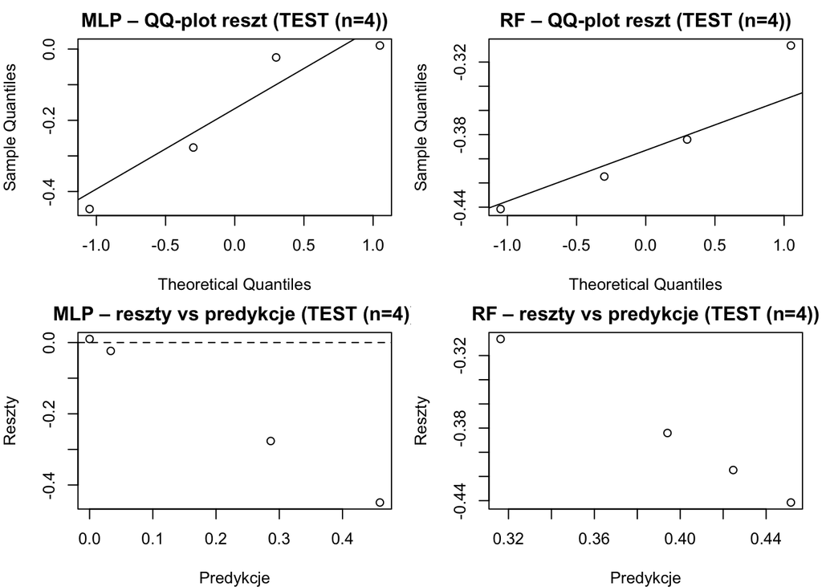

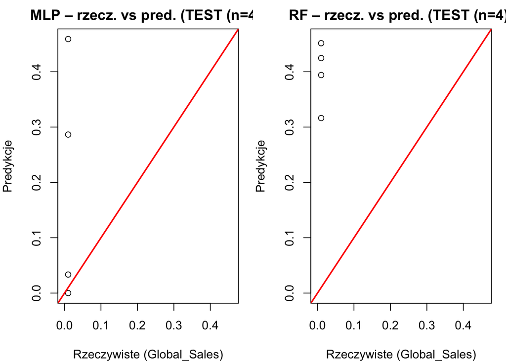

```r
plot_diagnostics(real_test,  pred_mlp_test,  pred_rf_test,  label = paste0("TEST (n=", N_TEST, ")"))
```

### Intepretacja wyników metryk

**1. Zbiór walidacyjny (VALID) - główna podstawa porównania**

Na zbiorze walidacyjnym model MLP osiagnął **lepszy (niższy) RMSE** niż Random Forest (1.0025 vs 1.0108), co oznacza mniejszy błąd średniokwadratowy. Przewaga modelu MLP jest jednak znacznie bardziej widoczna w metrykach opartych na błędzie bezwględnym:

- **MAE:** 0.3400 (MLP) vs 0.3915 (RF)
- **MedAE:** 0.1611 (MLP) vs 0.2553 (RF)

Dodatkowo obliczono metryki logarytmiczne oraz procentowe:

- sMAPE: 117.0006% (MLP) vs 115.3902% (RF)
- RMSLE: 0.2955 (MLP) vs 0.3080 (RF)

W przypadku błędu procentowego **sMAPE** wyniki modeli są zbliżone, z niewielką przewagą modelu Random Forest. sMAPE jest jednak bardzo wrażliwe na bardzo małe wartości sprzedaży, dlatego w dalszej analizie większy nacisk położono na metryki bezwzględne (MAE, MedAE) oraz RMSE.

Wartośc **R^2** dla modelu MLP wynosi 0.1416 (14.16%), co jest wynikiem lepszym od Random Forest (0.1274 = 12.74%). Poziom wyjasnianej zmienności jest niski, co jest charakterystyczne dla danych sprzedażowych pozbawionych cech marketingowych.

**Bias (ME)**, czyli ocena obciążenia modelu:

- **MLP:** -0.0114 => model wykazuje minimalną tendencję do zaniżania sprzedaży
- **Random Forest:** +0.0739 => model częściowo **zawyża** sprzedaż

**2. Zbiór testowy (TEST, n=4) - wyniki poglądowe**

Na bardzo małym zbiorze testowym metryki są mało stabilne, jednak potwierdzają przewagę modelu MLP.

- RMSE: 0.2640 (MLP) vs 0.3900 (RF)
- MAE: 0.1898 (MLP) vs 0.3866 (RF)
- MedAE: 0.1500 (MLP) vs 0.3994 (RF)

W tym przypadku także sMAPE jest niższe dla MLP (171.4748% vs 189.9924%), jednak wartości procentowe pozostają bardzo wysokie – co jest spójne z faktem, że gdy sprzedaże wielu gier są małe, to metryki procentowe wtedy mają bardzo duże wartości.

Na zbiorze tetsowym oba modele zawyżają sprzedaż (ME dodatnie), ale interpretacja jest poglądowa ze względu na n=4.

W tabeli pojawia się **R^2=-Inf** dla obu modeli. Nie oznacza to “katastrofalnie błędnego modelu”, tylko jest efektem technicznym. Przy bardzo małym zbiorze i/lub bardzo małej zmienności wartości rzeczywistych, składnik SS_tot może wyjść bliski zeru, co psuje interpetację R^2.

### Analiza wykresów diagnostycznych

Poniższe wykresy pokazują, jak wyglądają błędy i gdzie modele mają największe problemy.

**1. QQ_plot reszt** Na zbiorze VALID QQ-ploty reszt dla obu modeli (MLP i Random Forest) wyraźnie odchodzą od linii prostej w prawym ogonie rozkładu. Oznacza to obecność dużych dodatnich reszt, wynikających z niedoszacowania gier o bardzo wysokiej sprzedaży. Rozkład reszt nie spełnia założenia normalności, co jest typowe dla danych sprzedażowych o silnie prawostronnej asymetrii.

Kształt QQ-plotów jest bardzo podobny dla obu modeli, co wskazuje, że zarówno MLP, jak i Random Forest w podobnym stopniu mają trudności z odwzorowaniem ekstremalnych obserwacji.

**2. Reszty vs predykcje**

Na zbiorze VALID większość reszt skupia się w pobliżu zera, co wskazuje na poprawne predykcje dla „typowych” gier o niskiej i umiarkowanej sprzedaży. Wraz ze wzrostem wartości predykcji rośnie rozrzut reszt, co sugeruje występowanie heteroscedastyczności oraz trudności modeli w przewidywaniu bardzo wysokich sprzedaży.

**3. Rzeczywiste vs predykcje**

Na wykresie VALID oba modele wyraźnie mają problem z górnym zakresem rozkładu sprzedaży. Dla gier o bardzo wysokiej rzeczywistej sprzedaży punkty znajdują się znacząco poniżej linii idealnej predykcji, co wskazuje na systematyczne niedoszacowanie bardzo wysokich wartości sprzedaży przez oba modele.

Ze względu na bardzo małą liczność zbioru testowego (n = 4), wykresy diagnostyczne pełnią wyłącznie funkcję ilustracyjną i nie pozwalają na formułowanie wniosków statystycznych dotyczących rozkładu reszt.

### **Wnioski końcowe:**

1. Lepszym modelem na zbiorze walidacyjnym jest **MLP**, który osiągnął niższe wartości MAE i MedAE oraz lepszy RMSE.
2. Random Forest wykazuje dodatni bias, co oznacza tendencję do zawyżania predykcji sprzedaży.
3. Oba modele mają trudności z modelowaniem ekstremalnie wysokich sprzedaży, co jest widoczne zarówno w metrykach, jak i na wykresach diagnostycznych (niedoszacowywanie hitów)
4. Niska wartość R^2 wskazuje, że do dokładniejszego modelowania sprzedaży konieczne byłyby dodatkowe cechy opisujące czynniki rynkowe i jakościowe.

## DEPLOYMENT (wdrożenie)

Celem tego etapu jest określenie, w jaki sposób wybrany model predykcyjny może zostać wykorzystany w praktyce oraz jakie są jego ograniczenia w konetkście rzeczywistego zastosowania.

### Wybór modelu do wdrożenia:

Na podstawie uzyskanych wyników jako model docelowy do wdrozenia wybrano **MLP (Multi-Layer Perceptron)**. Decyzja ta wynika z:

- niższych błędów predykcji (niższe wartości metryk MAE i MedAE), co oznacza, że w przypadku typowej gry model myli się rzadziej
- minimalnie lepszego RMSE w porównaniu do Random Forest
- bardzo małego biasu (ME bliskie zeru), wskazującego na brak systematycznego zawyżania lub zaniżania prognoz.

Model **Random Forest** może być traktowany jako model referencyjny. W praktyce często służy jako punkt odniesienia, pozwalający ocenić, czy bardziej złożone modele przynoszą wymierne korzyści.

### **Ograniczenia modelu:**

- model systematycznie **niedoszacowuje** bardzo wysokich wartości sprzedaży (gry-hity)
- **niska wartość R^2** (na poziome ok. 14%) wskazuje, że znaczna część zmienności sprzedaży nie jest wyjaśniania przez dostępne cechy
- **brak zmiennych jakosciowych** ogranicza potencjal predykcyjny modelu

### **Utrzymanie i aktualizacja modelu:**

W praktycznym zastosowaniu model powinien być:

- okresowo ponownie trenowany wraz z pojawianiem się nowych danych sprzedażowych
- monitorowany pod względem wzrostu błędów predykcji
- rozszerzany o dodatkowe cechy, jesli staną się one dostępne

# PODSUMOWANIE:

Projekt zakończył się budową i porównaniem dwóch modeli regresyjnych służących do predykcji globalnej sprzedaży gier komputerowych: **MLP (Multi-Layer Perceptron)** oraz **Random Forest**. Zgodnie z założeniami metodyki CRISP-DM, proces obejmował pełny cykl analityczny — od zrozumienia problemu biznesowego i danych, poprzez przygotowanie danych i inżynierię cech, aż po modelowanie, ewaluację oraz interpretację wyników.

Model oparty na sieci neuronowej (MLP) osiągnął **lepsze wyniki predykcyjne** niż Random Forest, szczególnie w metrykach opartych na błędzie bezwzględnym (MAE, MedAE), co wskazuje na jego większą stabilność i trafność predykcji dla typowych gier o umiarkowanej sprzedaży. Random Forest charakteryzował się większą wrażliwością na obserwacje odstające, co skutkowało wyższymi błędami dla gier o niskiej i średniej sprzedaży.

Zastosowanie **transformacji logarytmicznej zmiennej docelowej** pozwoliło ograniczyć wpływ silnej prawostronnej asymetrii rozkładu sprzedaży oraz poprawić proces uczenia modeli. Jednocześnie analiza wykresów reszt oraz QQ-plotów wykazała, że oba modele mają trudności z dokładnym odwzorowaniem **ekstremalnych hitów sprzedażowych**, co jest bezpośrednio związane z charakterem danych oraz brakiem informacji o czynnikach marketingowych czy globalnych trendach.

Pomimo tych ograniczeń, zaproponowany model MLP **poprawnie identyfikuje typowe poziomy sprzedaży gier**, dzięki czemu może stanowić użyteczne narzędzie wspomagające analizę rynku, porównywanie potencjału tytułów w obrębie gatunków lub platform, a także wstępną ocenę oczekiwanej sprzedaży nowych produkcji.